# CCGL9065: Our Response to Climate Change: HK2100

Democracy and Capitalism

Dr. Hongshan Guo and Class

# Last Week’s Strategy: The Anchoring Trap

## Quick Callback

Last week’s strategy: **The Anchoring Trap**

*First number wins.*

**Anyone try it?** Did you lead with an extreme number before offering your “reasonable” version?

## Something You Took Away Last Week

Week 5 showed you that **every building is a climate decision.**

The Urban Heat Island effect — concrete absorbs heat, cities get hotter, AC demand rises, more fossil fuels burn, cities get *even hotter.*

You saw it in NYC (one park = 5°C difference), Vienna (turning trash into heat for 60,000 homes), and LA (paying people to rip out their lawns).

The built environment is a climate actor. But here’s the question: **even if we know the right design, who decides what gets built?**

## From Buildings → The Rules That Build Them

Last week: *“What did we build, and what does it cost the planet?”*

This week: *“Why don’t we build better — and whose fault is that?”*

**Same system. Bigger question.**

You can design the greenest building in the world, but if the economic incentives reward cheap construction and short-term profit, it won’t get built. The problem isn’t engineering — it’s **structural incentives.**

Your toolkit: Spectacle Formula → Complexity → System Boundaries → Timing → Built Environment → **now: Structural Incentives.**

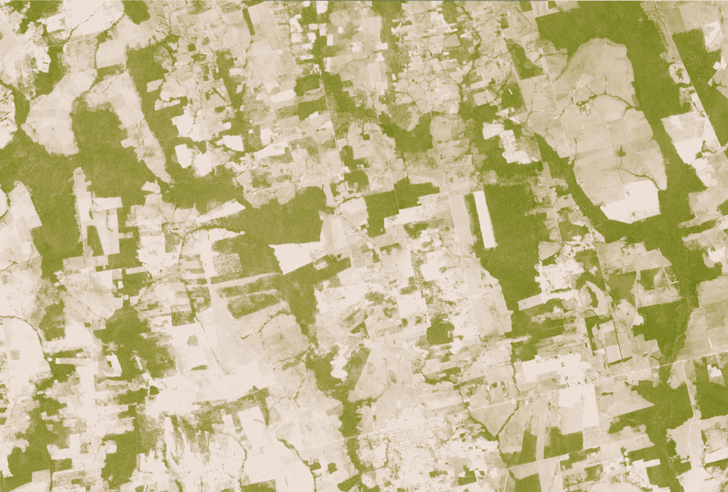

Rondônia, Brazil — NASA satellite, 2006. Each fishbone is a road. Each branch is a cleared farm. This used to be unbroken rainforest.

*No one decided to destroy the Amazon. Everyone just followed the incentives.*

# This Week’s Battlefield

## Two Sides. Two Economic Worldviews.

PRO-CLIMATE

= System Change

= “Capitalism caused this crisis”

PRO-DEVELOPMENT

= Market Solutions

= “Growth lifts all boats”

## The Core Tension

| PRO-CLIMATE | PRO-DEVELOPMENT |
| --- | --- |
| System change needed | Reform within system |
| Degrowth / post-growth | Green growth |
| Collective ownership | Private innovation |
| Regulation & mandates | Market incentives |
| Present suffering | Future prosperity |

**This tension appears in every economic climate debate.**

# From Energy to Capital

## The Oldest Energy Source

When was the earliest of all times that humans started to harvest energy?

Campfire.

[figure not shown]

Dark clouds of factory smoke obscure Clark Avenue Bridge, Cleveland, Ohio — US National Archives, 1970.

## From Campfire to Capital

Energy at scale created **surplus.** Surplus created **exchange.** Exchange created **markets.** Markets created **capital.**

- 1st Industrial Revolution → coal, steam, factory
- 2nd Industrial Revolution → oil, electricity, mass production
- Energy surplus at scale → source, transportation, end-user, importer

**The chain: energy → surplus → market → currency → capital → and now, war.**

Energy issues don’t arise in isolation — they arise at **scale.** And at scale, they become geopolitics.

“It is not from the benevolence of the butcher, the brewer, or the baker that we expect our dinner, but from their regard to their own interest.”

— Adam Smith, *The Wealth of Nations*, Book I, Chapter 2, 1776

Self-interest as engine. That’s the promise of capitalism — and the root of its climate problem.

## What Is Capital?

The accumulated wealth of an individual, company, or community, used as a fund for carrying on fresh production.

**Wealth in any form used to help produce more wealth.**

And what is capitalism?

“Capitalism” and “Capitalist” are 19th-century pejoratives — names given by its enemies. But the system itself has two faces:

- **Enormous productive capacity**
- **Always on the edge of being out of control**

## Who Is This Man?

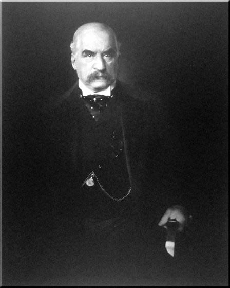

Photo by Edward Steichen.

- Does he look warm and fuzzy?
- What’s he holding?

This is **J.P. Morgan** — the man who personally bailed out the US government. Twice.

Capitalism has always had a face. Usually holding a cigar.

## Capitalism Is… (Per Karl Marx)

- A disease for which scientific socialism is the cure
- A method to steal the labour of the exploited masses
- *A system that undermines every traditionally established way of making a living*
- A system that inevitably undermines its own foundations.

## Capitalism Is… (Per Current Definitions)

A system defined by:

- **Private deployment of capital**
- **Open acknowledgement of profit as a motive**
- **Sympathetic understanding of self/household interests**
- **Tolerance for innovation** — though the characteristic fact of historical society is *resistance* to innovation as a kind of human nature

Hundreds of variations exist, but the essentials remain unchanged.

# Climate Change Meets Capitalism

## The Tragedy of the Commons

When individuals prioritise their own interests over common goods, the commons collapses.

This applies to:

- **Individuals** — driving, flying, consuming
- **Corporations** — externalising pollution costs
- **Nations** — free-riding on others’ emission cuts

A new economic system may help. But how?

“Ruin is the destination toward which all men rush, each pursuing his own best interest in a society that believes in the freedom of the commons.”

— Garrett Hardin, “The Tragedy of the Commons”, *Science*, Vol. 162, 1968

## See It: The Pattern That Keeps Repeating

[video not shown]

*TED-Ed (~5 min). The Tragedy of the Commons — from medieval grazing to climate collapse. The twist: communal management often works better than privatisation.*

## One Image. One Question.

BP invented the concept of a **“personal carbon footprint”** in 2005.

It was an ad campaign.

**You were the product.**

Structural problems require structural solutions. Individual guilt is a distraction.

“It is difficult to get a man to understand something, when his salary depends upon his not understanding it.”

— Upton Sinclair, *I, Candidate for Governor: And How I Got Licked*, 1935, p. 109

This is why oil executives don’t “believe in” climate change. They understand it fine. They’re paid not to.

## Carbon Pricing: Pay to Pollute?

The usual market solution to climate change: **price the pollution.**

| Mechanism | How It Works | The Problem |
| --- | --- | --- |
| **Carbon Tax** | Fixed price per tonne of CO₂ | Who sets the price? |
| **Carbon Credit** | Right to emit, tradeable | Government selling right to pollute? |
| **Carbon Offset** | Pay someone else to reduce | Does it actually reduce anything? |

What happens when the price target moves? When carbon becomes a commodity to trade *for profit*?

Now imagine you’re a government.

Oil just jumped **9% overnight** because of a military strike 8,000 km away.

Your citizens are paying more for petrol, electricity, groceries — **everything.**

And you want to add a carbon tax on top of that?

That’s not policy. That’s political suicide. And every fossil fuel lobby knows it.

## The Trap

This is the structural problem:

- **Peacetime:** carbon tax is unpopular but survivable
- **Crisis:** carbon tax becomes impossible — voters revolt
- **Oil companies know this.** They don’t need to fight the tax. They just need to wait for the next crisis.

And there is **always** a next crisis.

The PRO-CLIMATE position has a timing problem. The PRO-DEVELOPMENT position has a moral problem. Neither side wants to admit it.

# What If Growth Isn’t the Answer?

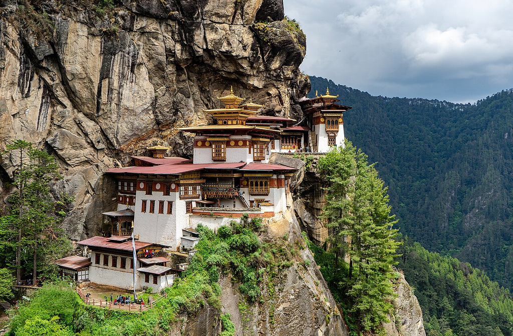

Paro Taktsang (Tiger’s Nest), Bhutan — a country that measures Gross National Happiness instead of GDP.

## The Post-Growth Challenge

A continued growth mindset is unsustainable. But what replaces it?

Alternative Models

- **Bhutan** — Gross National Happiness Index: well-being, conservation, cultural preservation
- **New Zealand** — Wellbeing Budget: mental health, child poverty, environment over GDP
- **Nordic Model** — free market + comprehensive welfare + collective bargaining

Collective Ownership

- **Mondragon** (Spain) — largest worker cooperative; workers own and operate
- **Community Land Trusts** (Boston, London) — nonprofit collective land ownership for affordable housing
- **Germany** — social market economy: free enterprise + social welfare + environmental protection

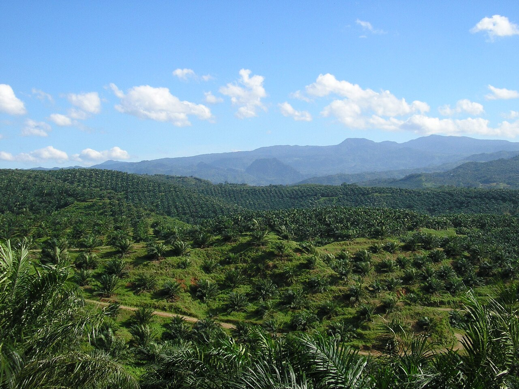

Oil palm plantation, Cigudeg, Indonesia — monoculture replacing rainforest. The market’s answer to “efficiency.”

## Mixed Economy: The Singapore Question

**Singapore’s blend:** competitive open markets + strong state intervention in housing, healthcare, and public transport.

**Germany’s blend:** capitalist economy + framework of social policies balancing enterprise with welfare and environmental protection.

The question isn’t capitalism vs. socialism. It’s: **what mix — and who decides?**

# Live Case Study: The War in Iran

On 28 February 2026, the US and Israel launched strikes on Iran.

Within **72 hours:**

- Oil jumped **~9%**
- The Strait of Hormuz effectively **closed**
- **15 million barrels/day** stopped moving
- Qatar’s LNG facilities were **hit by Iranian drones**

This isn’t a history slide. This is happening **right now.**

## Every Player Has an Agenda

| Player | What “Winning” Looks Like | The Energy Angle |
| --- | --- | --- |
| **USA** | Regime change. Destroy nuclear programme. Declare victory in <30 days. | Controls narrative but not the oil price. Domestic gas prices already spiking. |
| **Israel** | Iran implodes. Regional threat eliminated permanently. | No direct energy stake — but Gulf allies are furious. |
| **Iran** | Survive. Drag it out. Make the cost unbearable. | Strait of Hormuz is the weapon. Close it = global recession. |
| **Saudi Arabia / Gulf States** | Don’t get hit. Stay neutral. Protect oil infrastructure. | Iranian drones already struck airports, hotels, oil installations. Their worst nightmare. |
| **China** | Stability. Buys 90% of Iran’s oil exports. | 40% of China’s oil imports transit Hormuz. Acute supply risk. |
| **Europe** | Was told “minutes” before strikes began. Struggling to be heard. | LNG from Qatar = 20% of global supply, now disrupted. |

## The Chain Effect

**Step 1:** Strait of Hormuz closes → 31% of global seaborne crude halts

**Step 2:** Oil supertanker rates hit all-time high (**$424,000/day**, up 94%)

**Step 3:** Insurers cancel war-risk cover in the Gulf → shipping freezes

**Step 4:** Qatar LNG facilities hit → **20% of global LNG supply** offline

**Step 5:** Asia absorbs the pain — 70% of Hormuz crude goes to China, India, Japan, South Korea

**Step 6:** Thailand tells citizens not to panic-buy fuel. Pakistan and Bangladesh face blackouts.

One chokepoint. One week. The entire global energy system shudders.

Where is Hong Kong in this chain?

90% of HK’s electricity comes from fossil fuels.

How much of that fuel transits the Strait of Hormuz?

The built environment from Week 5 doesn’t just trap heat. It runs on a supply chain that passes through a war zone.

## Why This Belongs in a Capitalism Lecture

Every concept from today is in this story:

| This Week’s Concept | Where It Shows Up |
| --- | --- |
| **Structural Incentives** | Every player acts rationally — the outcome is catastrophic |
| **Tragedy of the Commons** | The Strait of Hormuz is the ultimate commons |
| **Carbon Pricing** | Your carbon tax is meaningless when oil jumps 9% overnight |
| **Disaster Capitalism** | Oil companies and arms manufacturers profit from the crisis |
| **Energy → Capital → War** | The chain we traced from campfire ends here |

The market doesn’t solve this. The market **is** this.

# Building Your Economic Spectacle

## The Formula (Reminder)

**Fact** + **Human Story** + **Stakes** = **Spectacle**

Weak

“Capitalism causes emissions”

Better

“100 companies produce 71% of global emissions”

Spectacle

“While you recycle, Shell knew about climate change in 1988 and spent millions denying it”

## PRO-CLIMATE: Make It Personal

**Don’t say:** “Carbon pricing has limitations.”

**Say:** “They want you to pay more for petrol while ExxonMobil gets tax breaks. You’re being charged for their mess.”

**Don’t say:** “We need systemic change.”

**Say:** “Your grandfather could afford a house on one salary. You can’t afford rent on two. That’s not laziness — that’s a system extracting everything from you.”

## PRO-DEVELOPMENT: Paint the Picture

**Don’t say:** “Markets drive innovation.”

**Say:** “In 2010, solar cost $378/MWh. Today: $36. That’s not government mandates — that’s competition. Capitalism did that.”

**Don’t say:** “We need economic growth.”

**Say:** “My grandmother grew up without electricity in rural China. Capitalism gave her grandchildren air conditioning, smartphones, and choices. Don’t take that away in the name of the planet.”

## What If the New Model Is Wrong?

Think Tesla. *(If you have to.)*

What happens if we switch to a new economic model and it fails?

| Risk | What Goes Wrong |
| --- | --- |
| **Economic Slowdown** | Growth stalls, jobs disappear |
| **Investment Displacement** | Capital moves to the wrong sectors |
| **Innovation Misdirection** | We solve the wrong problem (e.g. biofuels → deforestation) |
| **Cost of Living** | Carbon tax reflected in daily expenses |
| **Energy Insecurity** | One military strike closes the Strait of Hormuz — 15M barrels/day vanish |
| **Inequality** | Transition costs fall on those who can’t afford them |

The risk of changing is real. But so is the risk of not changing.

## This Week’s Debate Motion

**“This house believes that Hong Kong should impose a mandatory carbon tax on all businesses to fund its 2050 carbon neutrality target.”**

PRO-CLIMATE: Make polluters pay — structural change requires structural funding.

PRO-DEVELOPMENT: A carbon tax will kill HK’s competitiveness — innovation, not taxation, drives change.

# Activity: Economic Futures Debate

## Create Your Persona

**Lean PRO-CLIMATE?** Try being a…

- Labour union organiser fighting for just transition
- Economist advocating degrowth
- Community activist in a polluted industrial zone
- Youth climate striker

**Lean PRO-DEVELOPMENT?** Try being a…

- Hong Kong business owner worried about regulations
- Developing-nation finance minister
- Tech entrepreneur building “green” startups
- Traditional economist focused on GDP growth

Ask yourself: **What do I stand to lose?** That’s where your story begins.

## Human Story: The Shenzhen Factory Worker

**Mei Li** worked 12-hour shifts making electronics for $400/month. Her factory was shut down for “environmental violations.”

**PRO-CLIMATE says:** “Finally! That factory was poisoning the river. Workers like Mei deserve clean air.”

**PRO-DEVELOPMENT says:** “Mei lost her job. Her family went hungry. Now she begs on the street. Was the clean river worth it?”

**The real question:** How do we transition without leaving Mei behind?

*Both narratives are emotionally powerful. Both are incomplete. Your job: Find the fuller story.*

# Group Assignment Time!

## Presentation Countdown

00:00

# The Persuasion Playbook | Strategy #5

## The Specificity Illusion

Which is more believable?

A: *“The project will take a few weeks.”*

B: *“The project will take 17 days.”*

**B. Always B.** Even if both are equally made up.

## The Science

This is the **Specificity Heuristic**.

The brain uses detail as a proxy for credibility. Specific = precise = probably measured = probably true.

Con artists and skilled liars know this: add irrelevant detail and people stop questioning.

*“I was at the corner of 5th and Main at 3:47pm”* beats *“I was downtown that afternoon.”*

## You Just Saw It

Arguments that landed today had **unnecessary precision**:

- Not “lots of energy” → “415 TWh”
- Not “many people” → “240 million people”
- Not “recently” → “March 2024”

The detail signals: *I didn’t make this up.*

## Next Week’s Challenge

**Replace every vague word with a specific number, date, or name.**

Even if no one checks — they’ll believe you more.

# Appendix: Reference Materials

## Recommended Reading

| Book | Author | Why It Matters |
| --- | --- | --- |
| *Wealth of Nations* | Adam Smith | The founding text |
| *The Communist Manifesto* | Karl Marx | The founding critique |
| *The Constitution of Liberty* | Friedrich Hayek | The market conservative response |
| *A Farewell to Alms* | Gregory Clark | Capitalism: more and better? |
| *The Mystery of Capital* | Hernando de Soto | Why property rights precede development |
| *A Failure of Capitalism* | Richard Posner | A conservative judge’s honest assessment |
| *The Bottom Billion* | Paul Collier | Capital development to alleviate poverty |
| *The White Tiger* | Aravind Adiga | A poor, smart, flawed man in South India. Man Booker Prize, 2008. |

## Key Vocabulary

| Concept | Thinker | Core Idea |
| --- | --- | --- |
| **Capitalist Realism** | Fredric Jameson | Capitalism is the only viable system; alternatives are unimaginable |
| **Disaster Capitalism** | Naomi Klein | Exploitation of crises for profit |
| **Surveillance Capitalism** | Shoshana Zuboff | Using technology to monitor and control for profit |
| **Zero Marginal Cost Society** | Jeremy Rifkin | Technology makes goods virtually free → post-scarcity |
| **Green New Deal** | Various | Transition to carbon-neutral while promoting social justice |

## Cheatsheet: PRO-CLIMATE

**Arguments for a Resilient HK Economy:**

- **Green tech startups** — foster a competitive market for renewable energy
- **Circular economy models** — test sustainable business practices in HK
- **Public-private partnerships** — leverage private capital for smart city initiatives
- **Progressive regulation** — environmental rules that encourage (not punish) innovation
- **Carbon pricing** — incentivise low-carbon operations
- **Community-led initiatives** — public awareness + local sustainability projects

## Cheatsheet: PRO-DEVELOPMENT

**Arguments for HK’s Economic Stability:**

- **Growth first** — maintain a business-friendly environment, ensure job security
- **Proven strategies only** — avoid untested models that risk market disruption
- **Minimal regulation** — voluntary corporate sustainability, not mandates
- **Cost-benefit analysis** — evaluate green initiatives on ROI, protect SMEs
- **Incremental improvements** — gradual energy efficiency gains, low-risk green projects

## Fact-Check Guide

OK to Say

- “Shell knew about climate change in 1988” *(documented)*
- “Solar costs dropped 89% since 2010” *(IEA data)*
- “Bhutan measures Gross National Happiness” *(policy fact)*

NOT OK

- “Capitalism has killed millions” *(vague, unverifiable)*
- “Green policies destroy all jobs” *(exaggeration)*
- “Degrowth will solve everything” *(unfounded claim)*